# hw3

```python
import math
import pandas as pd
import numpy as np
from sklearn.model_selection import train_test_split
import matplotlib.pyplot as plt
from collections import defaultdict,Counter
from random import sample
```

```python
class DecisionNode():
    '''
    Constructor for decision node
    attr - attribute to be tested on
    thresh - threshold for numerical attr, if categorical set to none
    children - dict mapping attr value to child, if numeric child keys are 'le' and 'gr'
    label - class label. default None, if not none, indicates that this is a leaf
    '''
    def __init__(self, attr, children, label=None, thresh=None):
        self.attr = attr
        self.children = children
        self.label = label
        self.thresh = thresh

def learn_tree(data,attr_list,do_ig,attr_vals,targets,min_size_split=0,min_gain=0.0,max_depth=-1,maj_prop=1.0):
    '''
    Function to create decision tree based on data
    do_ig - boolean, True to use info gain, False to use gini critereon
    attr_vals - dict, maps to array of possible values for each attr, empty if numeric
    targets - array, possible values for target class
    min_size_split - int, min number of instances required in data before returning a leaf node
    min_gain - float, min info gain to determine when to stop
    max_depth - int, if -1 no depth limit, else maximum depth before stopping
    '''
    #if num data too small, return leaf
    if len(data) <= min_size_split:
        return DecisionNode(None,None,data['class'].mode()[0],None)
    #if max depth reached, return leaf
    if max_depth == 0:
        return DecisionNode(None,None,data['class'].mode()[0],None)

    if (data['class'].value_counts().iloc[0]/len(data)) >= maj_prop:
        return DecisionNode(None,None,data['class'].mode()[0],None)

    #find best attr from list using info gain
    max_gain = float('-inf')
    min_gini = float('inf')
    best_attr = ''

    random_attr = sample(attr_list,math.ceil(math.sqrt(len(attr_list))))

    for attr in random_attr:
        if do_ig:
            ig_attr,thresh = get_info_gain(data,attr,attr_vals[attr],targets)
            if ig_attr > max_gain:
                max_gain = ig_attr
                best_attr = attr
                best_thresh = thresh
        else:
            gini_attr = get_critereon(data,attr)
            if gini_attr < min_gini:
                min_gini = gini_attr
                best_attr = attr

    if best_attr == '':
        return DecisionNode(None,None,data['class'].mode()[0],None)

    best_vals = attr_vals[best_attr]
    best_children = defaultdict(lambda: DecisionNode(None,None,data['class'].mode()[0],None))

    #if numeric attr
    if len(best_vals) == 0:
        best_children['le'] = learn_tree(data.loc[data[best_attr] <= best_thresh],attr_list,do_ig,attr_vals,targets,min_size_split,max_gain,max_depth-1,maj_prop) if len(data.loc[data[best_attr] <= best_thresh]) > 0 else DecisionNode(None,None,data['class'].mode()[0],None)
        best_children['gr'] = learn_tree(data.loc[data[best_attr] > best_thresh],attr_list,do_ig,attr_vals,targets,min_size_split,max_gain,max_depth-1,maj_prop) if len(data.loc[data[best_attr] > best_thresh]) > 0 else DecisionNode(None,None,data['class'].mode()[0],None)

    else:
        for i in best_vals:
            next_child = learn_tree(data.loc[data[best_attr] == i],attr_list,do_ig,attr_vals,targets,min_size_split,max_gain,max_depth-1,maj_prop) if len(data.loc[data[best_attr] == i]) > 0 else DecisionNode(None,None,data['class'].mode()[0],None)
            best_children[i] = next_child

    return DecisionNode(best_attr,best_children,thresh=best_thresh)


#Helper functions for decision tree
def get_info_gain(data,attr,num_cat,targets):
    split_entropy = 0
    if len(num_cat) > 0:
        best_split = None
        for i in num_cat:
            split_data = data.loc[data[attr] == i]
            split_entropy += (entropy(split_data,targets)*len(split_data))/len(data)
    else:
        best_split = data[attr].mean()
        split_entropy += split_thresh(data,attr,best_split,targets)

    return (entropy(data,targets) - split_entropy),best_split

#determine split threshhold for numeric attr
def split_thresh(data,attr,thresh,targets):
    if math.isnan(thresh):
        return entropy(data,targets)
    df_le = data.loc[data[attr] <= thresh]
    df_g = data.loc[data[attr] > thresh]
    return (entropy(df_le,targets)*len(df_le) + entropy(df_g,targets)*len(df_g))/len(data)

def entropy(data,targets):
    if len(data) == 0:
        return 0
    ent = 0
    for i in range(len(targets)):
        try:
            prob_i = data['class'].value_counts().iloc[i]/len(data)
            ent -= (prob_i * math.log(prob_i,2))
        except:
            pass
    return ent

#function to classify an instance based on decision tree
def classify(instance,node):
    while node.label is None:
        if node.thresh is None:
            node = node.children[instance[node.attr]]
        else:
            node = node.children['le'] if instance[node.attr] <= node.thresh else node.children['gr']
    guess = node.label
    return guess

#wrapper fucntion for classify which takes all trees in forest, takes majority output and returns that guess
def ntree_classify(instance,ntree):
    votes = []
    for tree in ntree:
        votes.append(classify(instance,tree))
    count = Counter(votes)
    return count.most_common(1)[0][0]

#test accuracy on test data
def test_decision(to_test,targs,ntrees):
    predictions = pd.DataFrame(to_test.apply(lambda row: ntree_classify(row,ntrees), axis=1),columns = ['class'])
    predictions['actual'] = to_test.loc[predictions.index,['class']]
    prec,rec,f1 = [0,0,0]

    for val in targs:
        is_targ = predictions[predictions['class'] == val]
        not_targ = predictions[predictions['class'] != val]
        tp = len(is_targ[is_targ['class'] == is_targ['actual']])
        fp = len(is_targ[is_targ['class'] != is_targ['actual']])
        fn = len(not_targ[not_targ['actual'] == val])
        tn = len(not_targ[not_targ['actual'] != val])
        this_prec = (tp/(tp+fp)) if (tp+fp) > 0 else 0
        this_rec = (tp/(tp+fn)) if (tp+fn) > 0 else 0
        f1 += (this_prec*this_rec*2)/(this_rec+this_prec) if (this_rec+this_prec) > 0 else 0
        prec += this_prec
        rec += this_rec

    avg_prec = prec/len(targs)
    avg_rec = rec/len(targs)
    avg_f1 = f1/len(targs)
    accuracy = len(predictions[predictions['class'] == predictions['actual']])/len(to_test)
    return [accuracy,avg_prec,avg_rec,avg_f1]

np.random.seed(1)
k = 10
nvals = [1,5,10,20,30,40,50]
#function to do cross fold validation
def k_fold(fold,attr_list,attr_vals,targets,max_depth=7,min_size_split=10,maj_prop=0.9):
    #maps n vals to list of average statistics for each
    fold_metrics = defaultdict(list)
    #iterate through folds, taking turns being test fold
    for i in range(k):
        test_fold = fold[i]
        train_fold = fold[0:i]
        train_fold.extend(fold[i+1:len(fold)])
        train_data = pd.concat(train_fold)
        #vary number of trees for this fold
        for n in nvals:
            #list to store decisions of each tree by index
            ntree = []
            for j in range(n):
                #generate bootstrap w replacment
                bootstrap = train_data.sample(frac=1,replace=True)
                ntree.append(learn_tree(bootstrap,attr_list,True,attr_vals,targets,max_depth,min_size_split,maj_prop))
            fold_metrics[n].append(test_decision(test_fold,targets,ntree))
    return fold_metrics
```

## Notes:

### Stopping Criteria

- **max_depth**: the maximum depth of which a tree may go
- **min_size_split**: the minimum number of instances in a dataset before creating a leaf node
- **maj_prop**: if a dataset has instances of a target class >= this proportion, create a leaf node, this metric was used in HW1

### Performance Statistics

- Calculation of performance statistics can be seen in the `test_decision` function on line 127
- For recall, precision and F1 I calculated TP,FP,FN,TN for each target class, calculated scores for these values and then took the average across classes
- For accuracy, I simply took the number of correctly labeled instances / total, regardless of class

### General Implementation

- I decided to use the weak numerical threshold for splitting (average value of attribute for given dataset)
- K = 10 for cross fold validation

## 1. Wine Dataset

```python
wine_df = pd.read_csv('datasets/hw3_wine.csv',delim_whitespace=True)
wine_attr = defaultdict(list)
attr_list = list(wine_df.columns.values)
attr_list.remove('class')
wine_targets = [1,2,3]

#split data by class into k groups then combine into folds
wine_class_1 = wine_df.loc[wine_df['class'] == 1].sample(frac=1)
wc1_split = np.array_split(wine_class_1,k)
wine_class_2 = wine_df.loc[wine_df['class'] == 2].sample(frac=1)
wc2_split = np.array_split(wine_class_2,k)
wine_class_3 = wine_df.loc[wine_df['class'] == 3].sample(frac=1)
wc3_split = np.array_split(wine_class_3,k)

#list to hold folds
wine_fold = []
for i in range(k):
    this_fold = [wc1_split[i],wc2_split[i],wc3_split[i]]
    wine_fold.append(pd.concat(this_fold))

fold_metrics_wine = k_fold(wine_fold,attr_list,wine_attr,wine_targets,max_depth=7,min_size_split=10,maj_prop=0.875)
n_acc = []
n_prec = []
n_rec = []
n_f1 = []

for n,perf in fold_metrics_wine.items():
    avg_accuracy,avg_prec,avg_rec,avg_f1 = [0,0,0,0]
    for res in perf:
        avg_accuracy += res[0]
        avg_prec += res[1]
        avg_rec += res[2]
        avg_f1 += res[3]
    n_acc.append(avg_accuracy/10)
    n_prec.append(avg_prec/10)
    n_rec.append(avg_rec/10)
    n_f1.append(avg_f1/10)
```

**1.3** For each of the metrics described above, show a graph where you show the value of ntree on the x-axis, and where you show the value of the corresponding metric on the y-axis

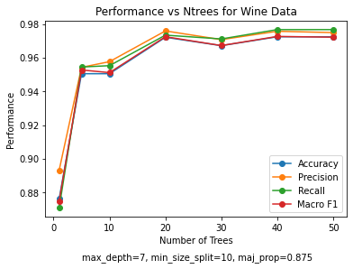

```python
plt.title('Performance vs Ntrees for Wine Data')
plt.xlabel('Number of Trees')
plt.ylabel('Performance')
plt.plot(nvals,n_acc,label='Accuracy',marker='o')
plt.plot(nvals,n_prec,label='Precision',marker='o')
plt.plot(nvals,n_rec,label='Recall',marker='o')
plt.plot(nvals,n_f1,label='Macro F1',marker='o')
plt.legend()
plt.text(5,0.84,'max_depth=7, min_size_split=10, maj_prop=0.875')
plt.show()
```

**1.4** For each metric being evaluated, discuss which value of ntree you would select if you were to deploy this classifier in real life. Explain your reasoning.

> In this case, I would choose N = 20 if I valued high precision, accuracy, and F1, as these values are maximized at N = 20. If i instead cared about recall, I would choose N = 40.

**1.5** Discuss (on a high level) which metrics were more directly affected by changing the value of ntree and, more generally, how such changes affected the performance of your algorithm. For instance: was the accuracy of the random forest particularly sensitive to increasing ntree past a given value? Was the F1 score a “harder” metric to optimize, possibly requiring a significant number of trees in the ensemble? Is there a point beyond which adding more trees does not improve performance—or makes the performance worse?

> It seems that for values of N > 20 precision falls while recall rises. While this is not always the case, over many runs F1 is generally stable for values of N > 10, making it hard to optimize for N past a certain upper limit. In general, increasing forests to N > 10 increases all performance metrics considerably, however they may peak before N = 50.

## 2. House Votes Dataset

```python
house_df = pd.read_csv('datasets/hw3_house_votes_84.csv')
#house_attr = defaultdict(lambda: [0,1,2])
house_attr_list = list(house_df.columns.values)
house_attr_list.remove('class')
house_attr = {key: [0,1,2] for key in house_attr_list}
house_targets = [0,1]
#split data by class into k groups then combine into folds
house_class_1 = house_df.loc[house_df['class'] == 0].sample(frac=1)
hc1_split = np.array_split(house_class_1,k)
house_class_2 = house_df.loc[house_df['class'] == 1].sample(frac=1)
hc2_split = np.array_split(house_class_2,k)

#list to hold folds
house_fold = []
for i in range(k):
    this_fold = [hc1_split[i],hc2_split[i]]
    house_fold.append(pd.concat(this_fold))

fold_metrics_house = k_fold(house_fold,house_attr_list,house_attr,house_targets,max_depth=8,min_size_split=25,maj_prop=0.875)
n_acc = []
n_prec = []
n_rec = []
n_f1 = []

for n,perf in fold_metrics_house.items():
    avg_accuracy,avg_prec,avg_rec,avg_f1 = [0,0,0,0]
    for res in perf:
        avg_accuracy += res[0]
        avg_prec += res[1]
        avg_rec += res[2]
        avg_f1 += res[3]
    n_acc.append(avg_accuracy/10)
    n_prec.append(avg_prec/10)
    n_rec.append(avg_rec/10)
    n_f1.append(avg_f1/10)
```

**1.3** For each of the metrics described above, show a graph where you show the value of ntree on the x-axis, and where you show the value of the corresponding metric on the y-axis

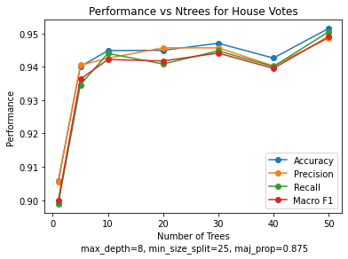

```python
plt.title('Performance vs Ntrees for House Votes')
plt.xlabel('Number of Trees')
plt.ylabel('Performance')
plt.plot(nvals,n_acc,label='Accuracy',marker='o')
plt.plot(nvals,n_prec,label='Precision',marker='o')
plt.plot(nvals,n_rec,label='Recall',marker='o')
plt.plot(nvals,n_f1,label='Macro F1',marker='o')
plt.legend()
plt.text(5,0.885,'max_depth=8, min_size_split=25, maj_prop=0.875')
plt.figure(figsize=(1,30))
plt.show()
```

**2.4** For each metric being evaluated, discuss which value of ntree you would select if you were to deploy this classifier in real life. Explain your reasoning.

> In this case, choosing N = 50 maximizes all perfmormance metrics, because of this I would use a forest with N = 50 in real deployment.

**2.5** Discuss (on a high level) which metrics were more directly affected by changing the value of ntree and, more generally, how such changes affected the performance of your algorithm. For instance: was the accuracy of the random forest particularly sensitive to increasing ntree past a given value? Was the F1 score a “harder” metric to optimize, possibly requiring a significant number of trees in the ensemble? Is there a point beyond which adding more trees does not improve performance—or makes the performance worse?

> In general, N > 1 yields a higher performance on all metrics considerably. For these forest, F1 and accuracy remain relatively stable while precision may jump and recall decrease for increasing values of N. This dataset seems to show far more variation in performance metrics across multiple runs of cross validation.

**(Extra Points #2: 8 Points)** Analyze a third dataset: the Breast Cancer Dataset. The goal, here, is to classify whether tissue removed via a biopsy indicates whether a person may or may not have breast cancer. There are 699 instances in this dataset. Each instance is described by 9 numerical attributes, and there are 2 classes. You should present the same analyses and graphs as discussed above. This dataset can be found in the same zip file as the two main datasets.

```python
cancer_df = pd.read_csv('datasets/hw3_cancer.csv',delim_whitespace=True)
cancer_attr = defaultdict(list)
attr_list = list(cancer_df.columns.values)
attr_list.remove('class')
cancer_targets = [0,1]

#split data by class into k groups then combine into folds
cancer_class_1 = cancer_df.loc[cancer_df['class'] == 0].sample(frac=1)
c1_split = np.array_split(cancer_class_1,k)
cancer_class_2 = cancer_df.loc[cancer_df['class'] == 1].sample(frac=1)
c2_split = np.array_split(cancer_class_2,k)
#list to hold folds
cancer_fold = []
for i in range(k):
    this_fold = [c1_split[i],c2_split[i]]
    cancer_fold.append(pd.concat(this_fold))
#,max_depth=10,min_size_split=30,maj_prop=0.85
fold_metrics_cancer = k_fold(cancer_fold,attr_list,cancer_attr,cancer_targets,max_depth=10,min_size_split=70,maj_prop=0.9)
n_acc = []
n_prec = []
n_rec = []
n_f1 = []

for n,perf in fold_metrics_cancer.items():
    avg_accuracy,avg_prec,avg_rec,avg_f1 = [0,0,0,0]
    for res in perf:
        avg_accuracy += res[0]
        avg_prec += res[1]
        avg_rec += res[2]
        avg_f1 += res[3]
    n_acc.append(avg_accuracy/10)
    n_prec.append(avg_prec/10)
    n_rec.append(avg_rec/10)
    n_f1.append(avg_f1/10)
```

[figure not shown]

```python
plt.title('Performance vs Ntrees for Cancer Data')
plt.xlabel('Number of Trees')
plt.ylabel('Performance')
plt.plot(nvals,n_acc,label='Accuracy',marker='o')
plt.plot(nvals,n_prec,label='Precision',marker='o')
plt.plot(nvals,n_rec,label='Recall',marker='o')
plt.plot(nvals,n_f1,label='Macro F1',marker='o')
plt.legend()
plt.text(5,0.875,'max_depth=8, min_size_split=25, maj_prop=0.875')
plt.show()
```

**EC 2.4** For each metric being evaluated, discuss which value of ntree you would select if you were to deploy this classifier in real life. Explain your reasoning.

> In this case, choosing N = 30 and 50 maximizes all perfmormance metrics, because of this I would use a forest with N = 30 in real deployment.

**EC 2.5** Discuss (on a high level) which metrics were more directly affected by changing the value of ntree and, more generally, how such changes affected the performance of your algorithm. For instance: was the accuracy of the random forest particularly sensitive to increasing ntree past a given value? Was the F1 score a “harder” metric to optimize, possibly requiring a significant number of trees in the ensemble? Is there a point beyond which adding more trees does not improve performance—or makes the performance worse?

> For this dataset the hardest metric to optimize was recall, which in turn effects F1. At N = 30, the recall does not improve further.

```python
contra_df = pd.read_csv('datasets/cmc.data')
contra_attr = defaultdict(list)
attr_list = list(contra_df.columns.values)
attr_list.remove('class')
contra_targets = [1,2,3]
#wife_age,wife_edu,hus_edu,num_child,num_child,wife_rel,wif_work,hus_ocu,stdi,media,class
contra_attr['wife_edu'].extend([1,2,3,4])
contra_attr['hus_edu'].extend([1,2,3,4])
contra_attr['wife_rel'].extend([0,1])
contra_attr['wif_work'].extend([0,1])
contra_attr['hus_ocu'].extend([1,2,3,4])
contra_attr['stdi'].extend([1,2,3,4])
contra_attr['media'].extend([0,1])
#split data by class into k groups then combine into folds
contra_class_1 = contra_df.loc[contra_df['class'] == 1].sample(frac=1)
c1_split = np.array_split(contra_class_1,k)
contra_class_2 = contra_df.loc[contra_df['class'] == 2].sample(frac=1)
c2_split = np.array_split(contra_class_2,k)
contra_class_3 = contra_df.loc[contra_df['class'] == 3].sample(frac=1)
c3_split = np.array_split(contra_class_3,k)
#list to hold folds
contra_fold = []
for i in range(k):
    this_fold = [c1_split[i],c2_split[i],c3_split[i]]
    contra_fold.append(pd.concat(this_fold))
#,max_depth=10,min_size_split=30,maj_prop=0.85
fold_metrics_cancer = k_fold(contra_fold,attr_list,contra_attr,contra_targets,max_depth=5,min_size_split=200,maj_prop=0.85)
n_acc = []
n_prec = []
n_rec = []
n_f1 = []

for n,perf in fold_metrics_cancer.items():
    avg_accuracy,avg_prec,avg_rec,avg_f1 = [0,0,0,0]
    for res in perf:
        avg_accuracy += res[0]
        avg_prec += res[1]
        avg_rec += res[2]
        avg_f1 += res[3]
    n_acc.append(avg_accuracy/10)
    n_prec.append(avg_prec/10)
    n_rec.append(avg_rec/10)
    n_f1.append(avg_f1/10)
```

[output not shown]

[output not shown]

[output not shown]

[figure not shown]

```python
plt.title('Performance vs Ntrees for Contraceptive Data')
plt.xlabel('Number of Trees')
plt.ylabel('Performance')
plt.plot(nvals,n_acc,label='Accuracy',marker='o')
plt.plot(nvals,n_prec,label='Precision',marker='o')
plt.plot(nvals,n_rec,label='Recall',marker='o')
plt.plot(nvals,n_f1,label='Macro F1',marker='o')
plt.legend()
plt.text(5,0.45,'max_depth=8, min_size_split=25, maj_prop=0.875')
plt.show()
```

```python
contra_df = pd.read_csv('datasets/cmc.data')
contra_attr = defaultdict(list)
attr_list = list(contra_df.columns.values)
attr_list.remove('class')
contra_targets = [1,2,3]
#wife_age,wife_edu,hus_edu,num_child,num_child,wife_rel,wif_work,hus_ocu,stdi,media,class
contra_attr['wife_edu'].extend([1,2,3,4])
contra_attr['hus_edu'].extend([1,2,3,4])
contra_attr['wife_rel'].extend([0,1])
contra_attr['wif_work'].extend([0,1])
contra_attr['hus_ocu'].extend([1,2,3,4])
contra_attr['stdi'].extend([1,2,3,4])
contra_attr['media'].extend([0,1])
#split data by class into k groups then combine into folds
contra_class_1 = contra_df.loc[contra_df['class'] == 1].sample(frac=1)
c1_split = np.array_split(contra_class_1,k)
contra_class_2 = contra_df.loc[contra_df['class'] == 2].sample(frac=1)
c2_split = np.array_split(contra_class_2,k)
contra_class_3 = contra_df.loc[contra_df['class'] == 3].sample(frac=1)
c3_split = np.array_split(contra_class_3,k)
#list to hold folds
contra_fold = []
for i in range(k):
    this_fold = [c1_split[i],c2_split[i],c3_split[i]]
    contra_fold.append(pd.concat(this_fold))
#,max_depth=10,min_size_split=30,maj_prop=0.85
fold_metrics_cancer = k_fold(contra_fold,attr_list,contra_attr,contra_targets,max_depth=5,min_size_split=500,maj_prop=0.85)
n_acc = []
n_prec = []
n_rec = []
n_f1 = []

for n,perf in fold_metrics_cancer.items():
    avg_accuracy,avg_prec,avg_rec,avg_f1 = [0,0,0,0]
    for res in perf:
        avg_accuracy += res[0]
        avg_prec += res[1]
        avg_rec += res[2]
        avg_f1 += res[3]
    n_acc.append(avg_accuracy/10)
    n_prec.append(avg_prec/10)
    n_rec.append(avg_rec/10)
    n_f1.append(avg_f1/10)
```